# Phylo spatial meta-analysis

Published

January 13, 2026

In this online tutorial, we demonstrate how to conduct phylogenetic and spatial meta-analyses using R packages such as `metafor`, `brms`, and `glmmTMB`. We provide step-by-step instructions on creating phylogenetic and spatial correlation matrices, fitting models with different correlation structures, and interpreting the results.

# Setup

```r
# install.packages("pacman") # if not already installed
pacman::p_load(brms, metafor, metadat, tidyverse, data.table, crayon, here, ape, patchwork,
               dplyr, tidyr, MCMCglmm, bayesplot, tidybayes, posterior, orchaRd,purrr, stringr, readr, lubridate, magrittr, janitor, glmmTMB, rotl, sf)
```

Set up parallel processing for `brms` - please adjust according to your computer’s capabilities.

```r
max_cores <- 10
num_chains <- 2
threads_per_chain <- floor(max_cores / num_chains)
options(mc.cores = num_chains)
```

# Phylogenetic meta-analysis

## How to make phylogenetic correlation matrix?

Before moving the each model, we show how to make phylogenetic correlation matrix. It is important to account for the shared evolutionary history of species. Most common way to do this is by incorporating a phylogenetic correlation matrix into your model. This matrix reflects how closely related species are,and can be derived in two main ways:

1. Using a specific phylogenetic tree
2. Using the `rotl` package (Open Tree of Life)

**Note**

Sometimes, the species names in your data may not match those in the tree - please ensure that they are consistent. Also, it will be necessity when dropping species from the tree that are not in your dataset. In that case, you can use `TreeTools::DropTip()` / `ape::drop.tip()` (or `TreeTools::KeepTip()` / `ape::keep.tip()`). You can see how to do this in the example below :)

**Using a specific phylogenetic tree**

In some cases, the phylogenetic relationships among the species of interest are already well established, and a corresponding phylogenetic tree is available from a published source or a public repository. When this is the case, it is usually preferable to use the existing tree rather than constructing a new one automatically. For example, large, time-calibrated phylogenies are available for many taxonomic groups (e.g. birds, mammals, plants), often accompanied by branch lengths and documentation of the underlying assumptions. Using such trees ensures consistency with previous studies and avoids unnecessary reconstruction steps.

Below, we illustrate how to use a phylogenetic tree provided as a file and prepare it for use in downstream analyses, such as phylogenetic meta-analysis.

#### Step 1. Read the tree from a file

Phylogenetic trees are commonly distributed in formats such as Newick (`.nwk`, `.tre`) or Nexus (`.nex`). The ape package can read most standard formats. We use a sample dataset on Sylviidae (passerines), which is a CSV file with species data and a Nexus file containing a phylogenetic tree. The dataset only includes 10 species for didactic purposes, while the tree contains 294 species. So, we need to prune the tree to match the dataset…

```r
library(ape)

# Read dataset and phylogenetic tree

dat <- read.csv(here("data", "Sylviidae_dat.csv"))
dat$Phylo
#  [1] "Abroscopus_albogularis"      "Abroscopus_schisticeps"
#  [3] "Abroscopus_superciliaris"    "Achaetops_pycnopygius"
#  [5] "Acrocephalus_aedon"          "Acrocephalus_aequinoctialis"
#  [7] "Acrocephalus_agricola"       "Acrocephalus_arundinaceus"
#  [9] "Acrocephalus_atyphus"        "Acrocephalus_australis"

# If the file contains multiple trees, select a single representative tree
trees <- read.nexus(here("data", "Sylviidae.nex"))

tree <- trees[[1]]  # select the first
```

#### Step 2. Basic structural checks

Before using the tree in analyses, it is good practice to perform some basic checks to ensure that the tree structure is appropriate.

```r
# Check whether the tree is ultrametric (time-calibrated)
is.ultrametric(tree)
# [1] TRUE

# Check whether the tree is fully bifurcating
is.binary(tree)
# [1] TRUE
```

#### Step 3. Match tree tip labels to the dataset

The species names in the tree must match exactly the species identifiers used in the dataset.

```r
# species names used in the dataset
species_data <- unique(dat$Phylo)

length(tree$tip.label)
# [1] 294
length(species_data)
# [1] 10

# check for mismatches between tree tip labels and dataset species names
setdiff(species_data, tree$tip.label)
setdiff(tree$tip.label, species_data)
```

If mismatches occur, theytypically reflect typographical errors, outdated taxonomy, or diffrences in naming conventions (e.g., underscores vs spaces), These issues must be resolved manually before proceeding.

#### Step 4. Prune the tree to include only species in the dataset

Phylogenetic trees often contain more species than required for a given analysis, Extraneous tips should be removed to match the dataset.

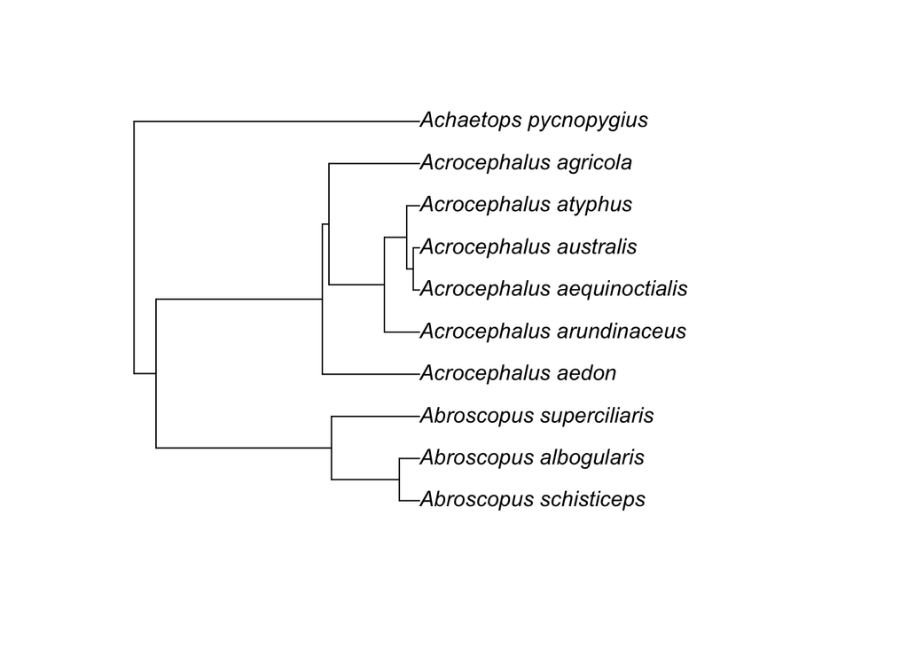

```r
tree_pruned  <- drop.tip(
  tree,
  setdiff(tree$tip.label, species_data)
  )

tree_pruned
plot(tree_pruned) # check the pruned tree
```

```r
# check the binary and ultrametric status again
is.binary(tree_pruned)
# [1] TRUE

is.ultrametric(tree_pruned)
# [1] TRUE
```

#### Step 5. Compute the phylogenetic correlation matrix

Once the tree is time-calibrated, fully bifurcating, and pruned to match the dataset, you can compute the phylogenetic correlation matrix under a Brownian motion model using the `vcv()` function from the `ape` package.

```r
A <-  vcv(tree_pruned, corr = TRUE)
# check the dimensions and preview the top-left block
dim(A)
```

This matrix represents the expected correlation among species due to shared evolutionary history and can ve used directly in phylogenetic comparative or meta-analytic models.

**Using the rotl package (Open Tree of Life)**

Life is not so that easy that you always have a phylogenetic tree for your species of interest. In such cases, you can use the `rotl` package to access the Open Tree of Life database and retrieve a phylogenetic tree based on the *Latin* species names in your dataset.

**Note**

- Make sure that the species names in your dataset are in Latin (scientific names) and are spelled correctly. The `rotl` package relies on these names to find the corresponding species in the Open Tree of Life (https://opentreeoflife.github.io/use).
- The OpenTree synthetic tree and name resolution services are actively updated. Running the same code at different times may yield slightly different trees due to updates in the database.
- For reproducible research, it is good practice to save the retrieved tree to a file (e.g., in Newick or Nexus format) after obtaining it using `rotl`. This way, you can ensure that you are using the same tree in future analyses.
- Automated name matching is convenient but may not always be perfect. It is advisable to manually check the matched names to ensure accuracy.

```r
# install and load necessary packages - if not already installed
# install.packages("rotl")
# install.packages("ape")

library(rotl)
library(ape)

# record info about OpenTree version
tol_about()
# OpenTree Synthetic Tree of Life.

# Tree version: opentree16.1
# Taxonomy version: 3.7draft3
# Constructed on: 2025-12-20 00:55:58
# Number of terminal taxa: 2385875
# Number of source trees: 2064
# Number of source studies: 1931
# Source list present: false
# Root taxon: cellular organisms
# Root ott_id: 93302
# Root node_id: ott93302
```

#### Step 1. Provide a species list

```r
myspecies <- c(
  "Escherichia colli",                # typo on purpose
  "Chlamydomonas reinhardtii",
  "Drosophila melanogaster",
  "Arabidopsis thaliana",
  "Rattus norvegicus",
  "Mus musculus",
  "Cavia porcellus",
  "Xenopus laevis",
  "Saccharomyces cervisae",           # typo on purpose
  "Danio rerio"
)
```

#### Step 2. Resolve species names using OpenTree TNRS

We first try a strict match, and then a fuzzy match for any unmatched names. This is useful to detect typos or synonyms in species names.

```r
taxa_strict <- tnrs_match_names(
  names = myspecies,
  do_approximate_matching = FALSE
  )
#   Warning message:
# Escherichia colli, Saccharomyces cervisae are not matched

taxa_strict
#                search_string               unique_name approximate_match score
# 1          escherichia colli                      <NA>                NA    NA
# 2  chlamydomonas reinhardtii Chlamydomonas reinhardtii             FALSE     1
# 3    drosophila melanogaster   Drosophila melanogaster             FALSE     1
# 4       arabidopsis thaliana      Arabidopsis thaliana             FALSE     1
# 5          rattus norvegicus         Rattus norvegicus             FALSE     1
# 6               mus musculus              Mus musculus             FALSE     1
# 7            cavia porcellus           Cavia porcellus             FALSE     1
# 8             xenopus laevis            Xenopus laevis             FALSE     1
# 9     saccharomyces cervisae                      <NA>                NA    NA
# 10               danio rerio               Danio rerio             FALSE     1
#     ott_id is_synonym flags number_matches
# 1       NA         NA  <NA>             NA
# 2    33153      FALSE                    1
# 3   505714      FALSE                    1
# 4   309263      FALSE                    1
# 5   271555      FALSE                    1
# 6   542509      FALSE                    1
# 7   744000      FALSE                    1
# 8   465096      FALSE                    1
# 9       NA         NA  <NA>             NA
# 10 1005914      FALSE                    1

taxa <- tnrs_match_names(
  names = myspecies,
  do_approximate_matching = TRUE
)

taxa
#                search_string               unique_name approximate_match
# 1          escherichia colli          Escherichia coli              TRUE
# 2  chlamydomonas reinhardtii Chlamydomonas reinhardtii             FALSE
# 3    drosophila melanogaster   Drosophila melanogaster             FALSE
# 4       arabidopsis thaliana      Arabidopsis thaliana             FALSE
# 5          rattus norvegicus         Rattus norvegicus             FALSE
# 6               mus musculus              Mus musculus             FALSE
# 7            cavia porcellus           Cavia porcellus             FALSE
# 8             xenopus laevis            Xenopus laevis             FALSE
# 9     saccharomyces cervisae  Saccharomyces cerevisiae              TRUE
# 10               danio rerio               Danio rerio             FALSE
#        score  ott_id is_synonym          flags number_matches
# 1  0.9375000  474506      FALSE sibling_higher              2
# 2  1.0000000   33153      FALSE                             1
# 3  1.0000000  505714      FALSE                             1
# 4  1.0000000  309263      FALSE                             1
# 5  1.0000000  271555      FALSE                             1
# 6  1.0000000  542509      FALSE                             1
# 7  1.0000000  744000      FALSE                             1
# 8  1.0000000  465096      FALSE                             1
# 9  0.9166667  356221      FALSE                             2
# 10 1.0000000 1005914      FALSE                             1
```

If the strict match fails or returns NAs, you can enable approximate matching. Approximate matching uses fuzzy string matching to find the closest matches in the OpenTree taxonomy (but you should always check the returned matches).

Key columns to check include: - `unique_name`: the matched OpenTree taxon name - `ott_id`: the OpenTree taxonomy identifier used for tree retrieval - `approximate_match`: `TRUE` indicates a non-exact match (for example due to a typo) - `is_synonym`: `TRUE` indicates the input name was treated as a synonym

A practical rule of thumb is the following: - If `approximate_match == TRUE` and the reason is an obvious typo (e.g. misspelling of a well-known species name), correct the original species list and re-run the name matching. This ensures that the final dataset contains clean and unambiguous names. - If a match looks suspicious (for example, the matched taxon belongs to a different genus, or the name could plausibly refer to multiple taxa), do not accept the match blindly. Instead, inspect the additional information returned by `tnrs_match_names()` to confirm that the matched taxon is indeed the one you intended to include.

#### Step 3. Fix typos and re-run matching

```r
myspecies_fixed <- c(
  "Escherichia coli",
  "Chlamydomonas reinhardtii",
  "Drosophila melanogaster",
  "Arabidopsis thaliana",
  "Rattus norvegicus",
  "Mus musculus",
  "Cavia porcellus",
  "Xenopus laevis",
  "Saccharomyces cerevisiae",
  "Danio rerio"
)

taxa_fixed <- tnrs_match_names(
  names = myspecies_fixed,
  do_approximate_matching = FALSE
)

# taxa_fixed
#                search_string               unique_name approximate_match score
# 1           escherichia coli          Escherichia coli             FALSE     1
# 2  chlamydomonas reinhardtii Chlamydomonas reinhardtii             FALSE     1
# 3    drosophila melanogaster   Drosophila melanogaster             FALSE     1
# 4       arabidopsis thaliana      Arabidopsis thaliana             FALSE     1
# 5          rattus norvegicus         Rattus norvegicus             FALSE     1
# 6               mus musculus              Mus musculus             FALSE     1
# 7            cavia porcellus           Cavia porcellus             FALSE     1
# 8             xenopus laevis            Xenopus laevis             FALSE     1
# 9   saccharomyces cerevisiae  Saccharomyces cerevisiae             FALSE     1
# 10               danio rerio               Danio rerio             FALSE     1
#     ott_id is_synonym          flags number_matches
# 1   474506      FALSE sibling_higher              1
# 2    33153      FALSE                             1
# 3   505714      FALSE                             1
# 4   309263      FALSE                             1
# 5   271555      FALSE                             1
# 6   542509      FALSE                             1
# 7   744000      FALSE                             1
# 8   465096      FALSE                             1
# 9   356221      FALSE                             1
# 10 1005914      FALSE                             1
```

At this point, you should confirm that: - All species have a valid ott_id. - The returned matches correspond to the intended taxa.

#### Step 4. Retrieve the phylogenetic tree from OpenTree

Once you are satisfied with the matched OpenTree identifiers, you can request a trimmed subtree from the OpenTree synthetic tree using `tol_induced_subtree()`.

```r
tree <- tol_induced_subtree(
  ott_ids = taxa_fixed[["ott_id"]],
  label_format = "name"
)
# we can get a Warning meassage here about collapsing single nodes - this is fine.
```

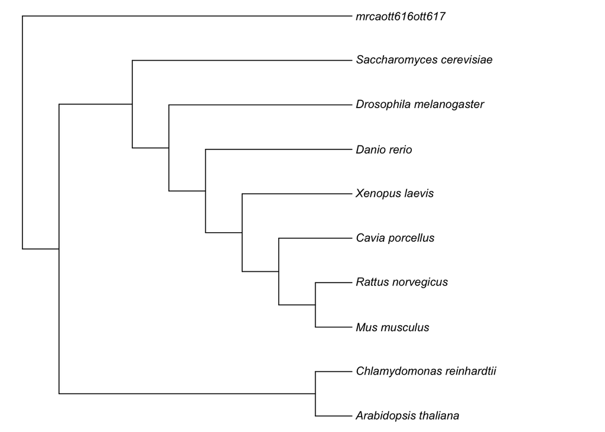

#### Step 5. Clean and standardise tip labels

OpenTree tip labels can include underscores, and sometimes a tip represents a non-taxon internal node (such as an MRCA node). This often happens when only one representative from a large clade is included (e.g., a single bacterial species).

```r
tree$tip.label # see the current tree tip labels
#  [1] "Arabidopsis_thaliana"      "Chlamydomonas_reinhardtii"
#  [3] "Mus_musculus"              "Rattus_norvegicus"
#  [5] "Cavia_porcellus"           "Xenopus_laevis"
#  [7] "Danio_rerio"               "Drosophila_melanogaster"
#  [9] "Saccharomyces_cerevisiae"  "mrcaott616ott617"

# Replace underscores with spaces for readability
tree$tip.label <- gsub("_", " ", tree$tip.label)

# Relabel MRCA-like tips for didactic plotting purposes
ecoli <- tol_node_info(ott_id = 474506, include_lineage = TRUE)
tax_lineage(ecoli) # domain within Bacteria
#      rank               name        unique_name ott_id
# 1  domain           Bacteria           Bacteria 844192
# 2 no rank cellular organisms cellular organisms  93302

tnrs_match_names(names = ("Escherichia"))  # we can see what info is available for this genus - not much, looks like a messy bit of a tree flagged as "INCONSISTENT"
tree$tip.label <- gsub("mrcaott616ott617", "Escherichia coli", tree$tip.label) # replace the tip label back with our species name
```

It is time to plot and tidy up the tree (note no branch lengths are included, they can be created later via simulations).

[output not shown]

[output not shown]

[output not shown]

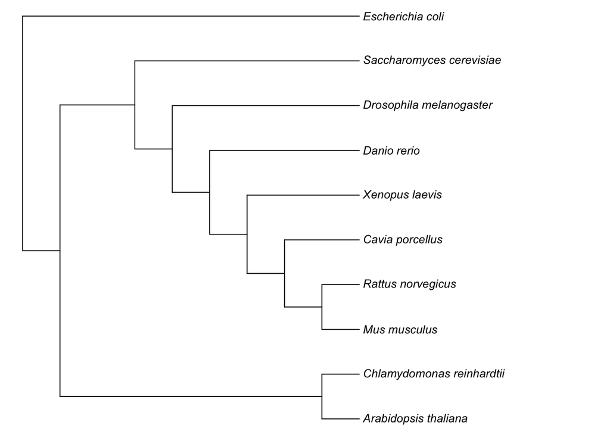

#### Step 6. Final checks (binary tree and matching tip labels)

Before using the tree in downstream analyses, it is good practice to confirm that: 1. The tree is fully binary (no polytomies), if that is required for your method. 2. The tip labels match exactly the species list in your dataset.

```r
# check whether the tree is binary
is.binary(tree) # should return TRUE
# [1] TRUE

# check exact matching between the species list and tree tip labels
intersect(as.character(tree$tip.label), myspecies_fixed)
#  [1] "Arabidopsis thaliana"      "Chlamydomonas reinhardtii"
#  [3] "Mus musculus"              "Rattus norvegicus"
#  [5] "Cavia porcellus"           "Xenopus laevis"
#  [7] "Danio rerio"               "Drosophila melanogaster"
#  [9] "Saccharomyces cerevisiae"  "Escherichia coli"

setdiff(myspecies_fixed, as.character(tree$tip.label))
# character(0)
setdiff(as.character(tree$tip.label), myspecies_fixed)
# character(0)
```

#### Step 7. Compute the phylogenetic correlation matrix (handling missing branch lengths)

To compute a phylogenetic variance covariance (VCV) or correlation matrix under a Brownian motion (BM) process, we use `vcv()` from the `ape` package. Importantly, `vcv()` requires branch lengths. However, the Open Tree of Life synthetic tree often provides a well-resolved tpology but does not always include branch lengths.

If the tree has no branch lengths, `vcv()` will fail with:

```r
A <- vcv(tree, corr = TRUE)
# Error in vcv.phylo(tree, corr = TRUE) : the tree has no branch lengths
```

For didactic purposes in this tutorial, we assign equal branch lengths to all edges (that is, all branch lengths are set to 1). This allows us to demonstrate the workflow and obtain a valid correlation matrix. In real analyses, you should consider using a tree with biologically meaningful branch lengths (for example, a time-calibrated phylogeny).

```r
# check whether the OpenTree synthetic tree includes branch lengths
is.null(tree$edge.length)
# [1] TRUE # TRUE indicates that branch lengths are missing

# if branch lengths are missing, add equal branch lengths for didactic purposes
if (is.null(tree$edge.length)) {
  tree$edge.length <- rep(1, nrow(tree$edge))
  }

# compute the phylogenetic correlation matrix under Brownian motion
A <- vcv(tree, corr = TRUE)

# check the dimensions and preview the top-left block
dim(A)        # should return the number of species (rows/columns)
# [1] 10 10

A[1:5, 1:5]
#                           Arabidopsis_thaliana Chlamydomonas_reinhardtii
# Arabidopsis_thaliana                 1.0000000                 0.6666667
# Chlamydomonas_reinhardtii            0.6666667                 1.0000000
# Mus_musculus                         0.2041241                 0.2041241
# Rattus_norvegicus                    0.2041241                 0.2041241
# Cavia_porcellus                      0.2182179                 0.2182179
#                           Mus_musculus Rattus_norvegicus Cavia_porcellus
# Arabidopsis_thaliana         0.2041241         0.2041241       0.2182179
# Chlamydomonas_reinhardtii    0.2041241         0.2041241       0.2182179
# Mus_musculus                 1.0000000         0.8750000       0.8017837
# Rattus_norvegicus            0.8750000         1.0000000       0.8017837
# Cavia_porcellus              0.8017837         0.8017837       1.0000000
```

**What if there are polytomies or non-ultrametric trees?**

A polytomy occurs when an internal node has more than two descendant branches (a multifurcation).  
A non-ultrametric tree is a tree in which not all tips are equidistant from the root, meaning that the tree is not time-calibrated.

Many phylogenetic comparative and meta-analytic models assume a fully bifurcating and ultrametric tree, because the expected covariance among species is defined under a continuous-time branching process (for example Brownian motion or Ornstein–Uhlenbeck evolution).  
Here we illustrate what these issues mean, and how they can be handled, using a simple toy example.

#### Create a toy tree with a polytomy

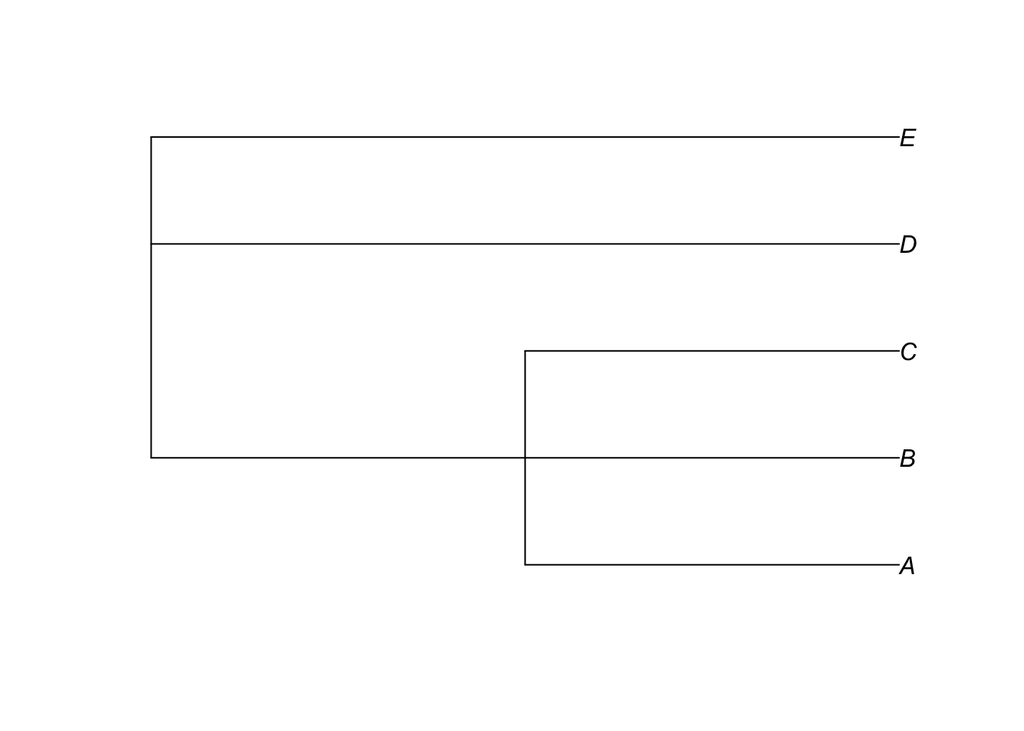

```r
library(ape)
library(phytools)

# A simple tree with one polytomy (A, B, C diverge simultaneously)
tree_poly <- read.tree(text = "((A,B,C),D,E);")
plot(tree_poly)
is.binary(tree_poly)
# [1] FALSE
```

Here, A, B, and C form a polytomy because their common ancestor has three descendants instead of two…

Under a Brownian motion or OU model, the phylogenetic covariance matrix is derived from branch lengths along a fully specified bifurcating tree.  
When a node is a polytomy, the relative order of divergence among its descendants is undefined, which means that their shared evolutionary history cannot be uniquely translated into a covariance structure.

#### Resolving polytomies

`multi2di()` resolves a polytomy by inserting very short branches, creating an arbitrary but fully bifurcating tree. This corresponds to assuming that the true branching order is unknown but occurred over a very short evolutionary time.

```r
set.seed(1)

tree_bin <- multi2di(tree_poly, random = TRUE)
is.binary(tree_bin)
# [1] TRUE
```

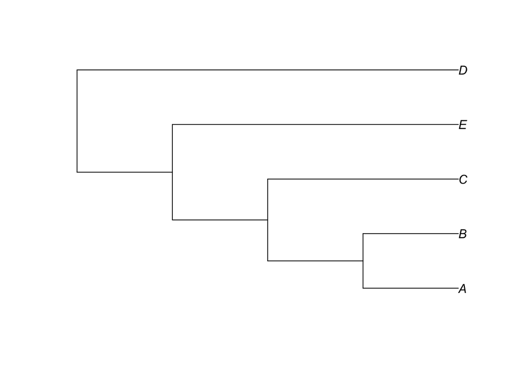

Because the resolution is random, different runs of `multi2di()` will yield different bifurcating trees. If you want reproducible results, set a random seed before calling `multi2di()`.

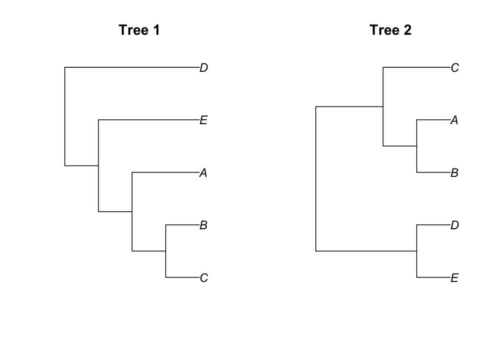

```r
set.seed(15)
tree_bin1 <- multi2di(tree_poly, random = TRUE)
set.seed(50)
tree_bin2 <- multi2di(tree_poly, random = TRUE)

par(mfrow = c(1,2))
plot(tree_bin1); title("Tree 1")
plot(tree_bin2); title("Tree 2")
```

```r
par(mfrow = c(1,1))
```

#### Create a non-ultrametric toy tree

```r
tree_nonultra <- read.tree(text = "((A:2,B:2):3,(C:1,D:4):2,E:5);")
is.ultrametric(tree_nonultra)
# [1] FALSE
```

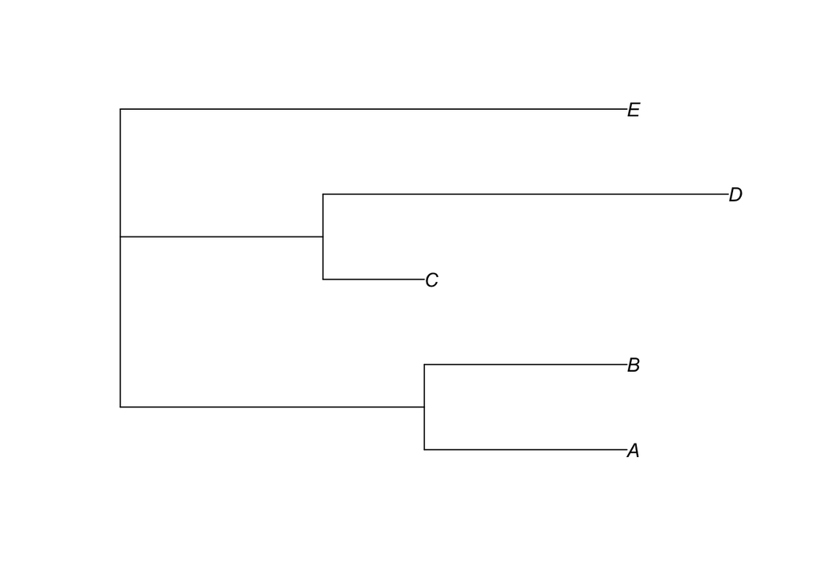

As you can see, the tips do not all end at the same distance from the root, so the tree is not ultrametric. This means that branch lengths cannot be interpreted directly as shared evolutionary time, which is required for Brownian motion or Ornstein–Uhlenbeck based phylogenetic covariance models.

`chronos()` estimates branch lengths under a relaxed molecular clock, producing a tree in which all tips represent the same present time.  
This is required when phylogenetic covariance is interpreted as shared evolutionary time.

```r
tree_ultra1 <- chronos(tree_nonultra)
is.ultrametric(tree_ultra1)
# [1] TRUE
```

```
Setting initial dates...
Fitting in progress... get a first set of estimates
         (Penalised) log-lik = -17.41843
Optimising rates... dates... -17.41843
Optimising rates... dates... -17.4165

log-Lik = -14.93714
PHIIC = 49.73
```

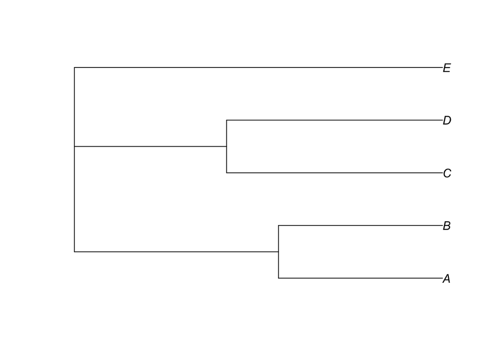

Or, you can use `force.ultrametric()` from the `phytools` package to coerce a tree into an ultrametric form by extending branch lengths.

```r
tree_ultra2 <- force.ultrametric(tree_nonultra, method = "extend")
is.ultrametric(tree_ultra2)
```

```
*                          Note:                              *
*    force.ultrametric does not include a formal method to    *
*    ultrametricize a tree & should only be used to coerce    *
*   a phylogeny that fails is.ultrametric due to rounding --  *
*    not as a substitute for formal rate-smoothing methods.   *
```

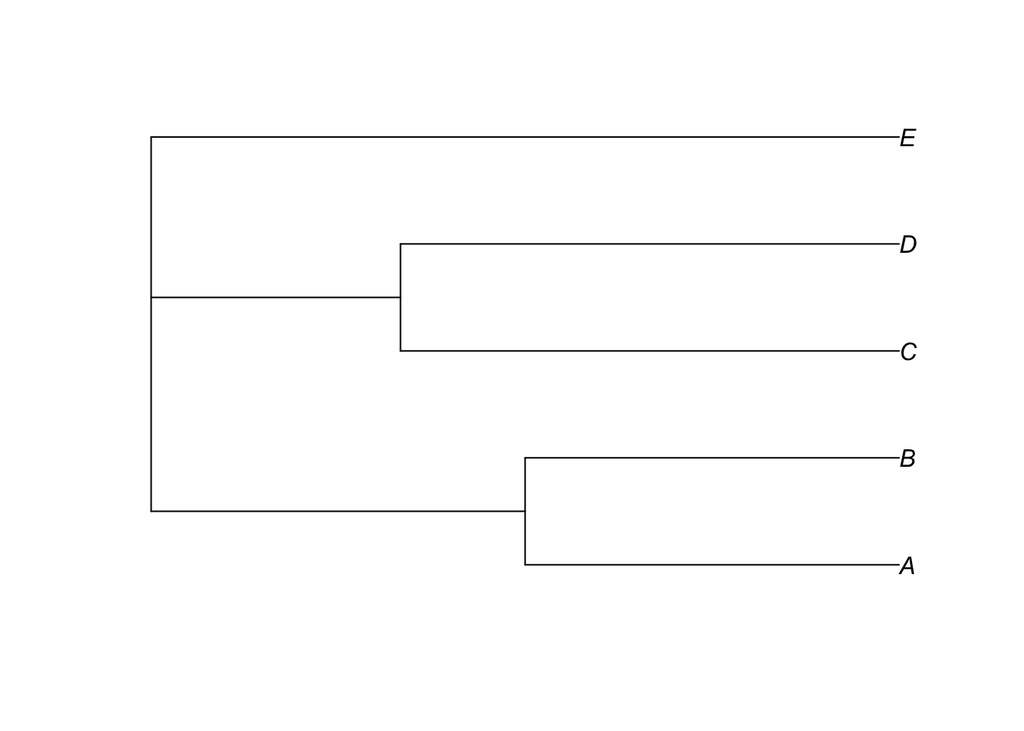

In practice, the typical workflow is:

1. Check whether the tree is binary and ultrametric.
2. If polytomies are present, resolve them using `multi2di()`, ideally multiple times.
3. If the tree is not ultrametric, apply a dating method such as `chronos()` or use a time-calibrated tree from the literature.
4. Only then compute the phylogenetic covariance or correlation matrix using `vcv()`.

This ensures that the phylogenetic random effect used in meta-analysis corresponds to a well-defined evolutionary model.

## Example

### Moura et al. (2021)

```r
dat_moura2021 <- dat.moura2021$dat
tree <- dat.moura2021$tree

# calculate r-to-z transformed correlations and corresponding sampling variances
dat_moura2021 <- escalc(measure="ZCOR", ri=ri, ni=ni, data=dat_moura2021)

# turn tree into an ultrametric one
tree <- compute.brlen(tree)

# compute phylogenetic correlation matrix
A <- vcv(tree, corr = TRUE)

# make copy of the species.id variable
dat_moura2021$species.id.phy <- dat_moura2021$species.id
```

**Brownian motion**

##### metafor

```r
system.time(
  phylo_eg1_meta_BM <- rma.mv(yi, vi,
         random = list(~ 1 | study.id,
         ~ 1 | effect.size.id,
         ~ 1 | species.id,
         ~ 1 | species.id.phy),
         R = list(species.id.phy=A),
         data = dat_moura2021,
         verbose = TRUE,
         sparse = TRUE,
         method = "REML"
         )
  )

summary(phylo_eg1_meta_BM)
# Multivariate Meta-Analysis Model (k = 1828; method: REML)
#
#    logLik   Deviance        AIC        BIC       AICc
# -167.6726   335.3453   345.3453   372.8974   345.3782
#
# Variance Components:
#
#             estim    sqrt  nlvls  fixed          factor    R
# sigma^2.1  0.0192  0.1384    457     no        study.id   no
# sigma^2.2  0.0145  0.1202   1828     no  effect.size.id   no
# sigma^2.3  0.0557  0.2359    341     no      species.id   no
# sigma^2.4  0.0512  0.2263    341     no  species.id.phy  yes
#
# Test for Heterogeneity:
# Q(df = 1827) = 10743.8076, p-val < .0001
#
# Model Results:
#
# estimate      se    zval    pval   ci.lb   ci.ub
#   0.3682  0.1300  2.8311  0.0046  0.1133  0.6230  **

confint(phylo_eg1_meta_BM)
#           estimate  ci.lb  ci.ub
# sigma^2.1   0.0192 0.0108 0.0325
# sigma.1     0.1384 0.1038 0.1802

#           estimate  ci.lb  ci.ub
# sigma^2.2   0.0145 0.0121 0.0172
# sigma.2     0.1202 0.1099 0.1311

#           estimate  ci.lb  ci.ub
# sigma^2.3   0.0557 0.0334 0.0788
# sigma.3     0.2359 0.1827 0.2807

#           estimate  ci.lb  ci.ub
# sigma^2.4   0.0512 0.0179 0.1792
# sigma.4     0.2263 0.1336 0.4233

orchaRd::i2_ml(phylo_eg1_meta_BM)
# I2_Total       I2_study.id I2_effect.size.id     I2_species.id I2_species.id.phy
# 97.30527          13.26902          10.00808          38.55098          35.47718

phylo_heritability <- phylo_eg1_meta_BM$sigma2[4] / (phylo_eg1_meta_BM$sigma2[4] + phylo_eg1_meta_BM$sigma2[3])
phylo_heritability
# [1] 0.479239
```

##### brms

```r
fit_phylo_eg1_brms <- bf(yi | se(sqrt(vi)) ~ 1 +
                     (1 | study.id) +
                     (1 | effect.size.id) +
                     (1 | species.id) +
                     (1 | gr(species.id.phy, cov = A))
                     )

prior_brms2 <- get_prior(
  formula = fit_phylo_eg1_brms,
  data = dat_moura2021,
  data2 = list(A = A),
  family = gaussian()
  )

system.time(
  phylo_eg1_brms <- brm(
    formula = fit_phylo_eg1_brms,
    family = gaussian(),
    data = dat_moura2021,
    data2 = list(A = A),
    prior = prior_brms2,
    iter = 10000,
    warmup = 7000,
    chains = num_chains,
    backend = "cmdstanr",
    threads = threading(threads_per_chain),
    control = list(adapt_delta = 0.95, max_treedepth = 15)
    )
  )

summary(phylo_eg1_brms)
#  Family: gaussian
#   Links: mu = identity
# Formula: yi | se(sqrt(vi)) ~ 1 + (1 | study.id) + (1 | effect.size.id) + (1 | species.id) + (1 | gr(species.id.phy, cov = A))
#    Data: dat_moura2021 (Number of observations: 1828)
#   Draws: 2 chains, each with iter = 10000; warmup = 7000; thin = 1;
#          total post-warmup draws = 6000
#
# Multilevel Hyperparameters:
# ~effect.size.id (Number of levels: 1828)
#               Estimate Est.Error l-95% CI u-95% CI Rhat Bulk_ESS Tail_ESS
# sd(Intercept)     0.12      0.01     0.11     0.13 1.00     2091     3894
#
# ~species.id (Number of levels: 341)
#               Estimate Est.Error l-95% CI u-95% CI Rhat Bulk_ESS Tail_ESS
# sd(Intercept)     0.23      0.03     0.17     0.28 1.00      795     1292
#
# ~species.id.phy (Number of levels: 341)
#               Estimate Est.Error l-95% CI u-95% CI Rhat Bulk_ESS Tail_ESS
# sd(Intercept)     0.27      0.09     0.14     0.50 1.00     1158      954
#
# ~study.id (Number of levels: 457)
#               Estimate Est.Error l-95% CI u-95% CI Rhat Bulk_ESS Tail_ESS
# sd(Intercept)     0.14      0.02     0.11     0.18 1.00      661     1223
#
# Regression Coefficients:
#           Estimate Est.Error l-95% CI u-95% CI Rhat Bulk_ESS Tail_ESS
# Intercept     0.37      0.16     0.05     0.70 1.00     3504     2965
#
# Further Distributional Parameters:
#       Estimate Est.Error l-95% CI u-95% CI Rhat Bulk_ESS Tail_ESS
# sigma     0.00      0.00     0.00     0.00   NA       NA       NA
```

Let’s calculate $I^2$ statistics to quantify the proportion of variance attributable to different sources of heterogeneity.

```r
fit <- phylo_eg1_brms
dat <- dat_moura2021
v_harm <- 1 / mean(1/dat$vi, na.rm = TRUE)

I2_total_harm  <- var_total_hetero / (var_total_hetero + v_harm)
I2_effect_harm <- var_effect      / (var_total_hetero + v_harm)
I2_study_harm  <- var_study       / (var_total_hetero + v_harm)
I2_species_harm<- var_species     / (var_total_hetero + v_harm)
I2_phylo_harm  <- var_phylo       / (var_total_hetero + v_harm)

round(rbind(
  total   = summ_I2(I2_total_harm),
  effect  = summ_I2(I2_effect_harm),
  study   = summ_I2(I2_study_harm),
  species = summ_I2(I2_species_harm),
  phylo   = summ_I2(I2_phylo_harm)
), 3)
#         mean q2.5.2.5% q50.50% q97.5.97.5%
# total   0.978     0.969   0.978       0.990
# effect  0.090     0.043   0.091       0.134
# study   0.129     0.048   0.123       0.247
# species 0.330     0.115   0.333       0.530
# phylo   0.429     0.178   0.414       0.759
```

##### glmmTMB

```r
A <- A[sort(rownames(A)), sort(rownames(A))]

dat_moura2021$g <- 1

VCV <- diag(dat_moura2021$vi, nrow = nrow(dat_moura2021))
rownames(VCV)<- colnames(VCV)<- dat_moura2021$effect.size.id

dat_moura2021$effect.size.id <- as.factor(dat_moura2021$effect.size.id)
head(dat_moura2021)

system.time(
    phylo_eg1_tmb <- glmmTMB(yi ~ 1 + equalto(0 + effect.size.id|g, VCV) +
                         (1|study.id) +
                         (1|species.id.phy) +
                         propto(0 + species.id.phy|g, A),
                       data = dat_moura2021,
                       REML = T)
    )
head(confint(phylo_eg1_tmb), 10)
#                                                                           2.5 %    97.5 %   Estimate
# (Intercept)                                                            0.1132610 0.6230707 0.3681658
# Std.Dev.(Intercept)|study.id                                           0.1056462 0.1813458 0.1384142
# Std.Dev.(Intercept)|species.id.phy                                     0.1932854 0.2879763 0.2359271
# Std.Dev.species.id.phyAcanthurus_leucosternon_ott388125|g.1            0.1293612 0.3959730 0.2263262
# Std.Dev.species.id.phyAcanthurus_nigricans_ott467313|g.1               0.1293612 0.3959730 0.2263262
# Std.Dev.species.id.phyAcanthurus_nigrofuscus_ott605289|g.1             0.1293612 0.3959730 0.2263262
# Std.Dev.species.id.phyAchatina_fulica_ott997087|g.1                    0.1293612 0.3959730 0.2263262
# Std.Dev.species.id.phyAegithalos_glaucogularis_vinaceus_ott5560982|g.1 0.1293612 0.3959730 0.2263262
# Std.Dev.species.id.phyAethia_pusilla_ott855484|g.1                     0.1293612 0.3959730 0.2263262
# Std.Dev.species.id.phyAgalychnis_callidryas_ott9483|g.1                0.1293612 0.3959730 0.2263262

sigma(phylo_eg1_tmb)^2
# [1] 0.01445014 # residual variance

phylo_eg1_tmb_varcor <- VarCorr(phylo_eg1_tmb)$cond
exp(phylo_eg1_tmb$fit$par)
#   betadisp      theta      theta      theta
# 0.12020875 0.13841423 0.23592711 0.05122353 <- residual variance (sd), study.id (sd), species.id (sd), species.id.phy (variance?)
```

**Ornstein-Uhlenbeck**

```r
# create phylogenetic distance matrix
dat_moura2021$const <- 1
I  <- matrix(1, nrow = length(tree$tip.label), ncol = length(tree$tip.label))
D <- I-A

D[1:5, 1:5]

system.time(
    phy_ou_meta <- rma.mv(yi, vi,
   random = list(~ 1 | study.id,
   ~ 1 | effect.size.id,
   ~ 1 | species.id,
   ~ species.id.phy | const),
   dist = list(D),
   struct = "SPEXP",
   control = list(rho.init = 1),
   data = dat_moura2021,
   verbose = TRUE,
   sparse = TRUE,
   method = "REML",
   test = "t"
   )
   )

summary(phy_ou_meta)
# Multivariate Meta-Analysis Model (k = 1828; method: REML)

#    logLik   Deviance       AIC        BIC       AICc
# -160.3783   320.7567   332.7567   365.8192   332.8028

# Variance Components:

#             estim    sqrt  nlvls  fixed          factor
# sigma^2.1  0.0157  0.1254    457     no        study.id
# sigma^2.2  0.0144  0.1201   1828     no  effect.size.id
# sigma^2.3  0.0000  0.0000    341     no      species.id

# outer factor: const           (nlvls = 1)
# inner term:   ~species.id.phy (nlvls = 341)

#             estim    sqrt  fixed
# tau^2      0.1029  0.3208     no
# rho        0.0182             no

# Test for Heterogeneity:
# Q(df = 1827) = 10743.8076, p-val < .0001

# Model Results:

# estimate      se    zval    pval   ci.lb   ci.ub
#   0.3514  0.0355  9.9090  <.0001  0.2819  0.4209  ***

# ---
# Signif. codes:  0 ‘***’ 0.001 ‘**’ 0.01 ‘*’ 0.05 ‘.’ 0.1 ‘ ’ 1

rho <- phy_ou_meta$rho  #[1] 0.01820382
alpha <- 1/rho # 54.93351
A_OU <- exp(-alpha*D)

system.time(
  phy_ou_meta1 <- rma.mv(yi, vi,
     random = list(~ 1 | study.id,
    ~ 1 | effect.size.id,
    ~ 1 | species.id,
    ~ 1 | species.id.phy),
    R = list(species.id.phy = A_OU),
    data = dat_moura2021,
    verbose = TRUE,
    sparse = TRUE,
    method = "REML",
    test = "t"
    )
)

summary(phy_ou_meta1)
# Multivariate Meta-Analysis Model (k = 1828; method: REML)
#
#    logLik   Deviance        AIC        BIC       AICc
# -160.3783   320.7567   330.7567   358.3088   330.7896
#
# Variance Components:
#
#             estim    sqrt  nlvls  fixed          factor    R
# sigma^2.1  0.0157  0.1254    457     no        study.id   no
# sigma^2.2  0.0144  0.1201   1828     no  effect.size.id   no
# sigma^2.3  0.0000  0.0001    341     no      species.id   no
# sigma^2.4  0.1029  0.3208    341     no  species.id.phy  yes
#
# Test for Heterogeneity:
# Q(df = 1827) = 10743.8076, p-val < .0001
#
# Model Results:
#
# estimate      se    tval    df    pval   ci.lb   ci.ub
#   0.3514  0.0355  9.9090  1827  <.0001  0.2819  0.4210  ***
```

Unfortunately, we cannot fit the OU model using `brms` or `glmmTMB` yet…

# Spatial meta-analysis

## How to make spatial correlation matrix?

In spatial meta-analysis, we model the residual similarity between effect sizes as a function of the geographic distance between their sampling locations. The key input is a representation of the pairwise distances among all effect sizes in the dataset. Depending on the spatial correlation structure assumed (for example, exponential, Gaussian, spherical), these distances are then transformed into a correlation matrix that describes the expected similarity between effect sizes based on their geographic proximity.

### Step 1. Ensure each effect size has geographic coordinates, a unique identifer and projected coordinates in km

Each effect size should have geographic coordinates (latitude and longitude) indicating where the data were collected. Because latitude and longitude are measured in degrees, we first project them to a planar coordinate reference system (CRS) and then convert the resulting coordinates to kilometres. This allows us to compute meaningful Euclidean distances.

```r
library(tidyverse)
library(sf)

toy_sites <- tibble(
  effect_id = 1:5,
  latitude = c(34.05, 36.16, 40.71, 34.05, 37.77),
  longitude = c(-118.24, -115.15, -74.00, -118.25, -122.42)
  )

# convert to an sf object (WGS84 longitude / latitude)
toy_sites_sf <- st_as_sf(
  toy_sites,
  coords = c("longitude", "latitude"),
  crs = 4326)

# project to a planar coordinate system and convert to kilometers
# EPSG:3857 is convenient for small-scale distance calculations
# for real analyses, consider using an appropriate local projection
toy_sites_sf_proj <- st_transform(toy_sites_sf, crs = 3857)

xy_m <- st_coordinates(toy_sites_sf_proj)
toy_sites$x_km <- xy_m[,1] / 1000
toy_sites$y_km <- xy_m[,2] / 1000
toy_sites
# A tibble: 5 × 5
#   effect_id latitude longitude    x_km  y_km
#       <int>    <dbl>     <dbl>   <dbl> <dbl>
# 1         1     34.0     -118. -13162. 4036.
# 2         2     36.2     -115. -12818. 4323.
# 3         3     40.7      -74   -8238. 4970.
# 4         4     34.0     -118. -13164. 4036.
# 5         5     37.8     -122. -13628. 4547.
```

The projected coordinates (x_km, y_km) can be negative because they represent positions relative to the origin of the coordinate system. We first assign a geographic CRS (EPSG:4326) to declare that the coordinates are in latitude and longitude.  
Then we transform the coordinates to a planar CRS (EPSG:3857) suitable for distance calculations, and convert the resulting x and y coordinates from meters to kilometres.

### Step 2. Compute pairwise *Euclidean* distance matrix

Once each effct size has projected coordinates in kilometres, we can compute the Euclidean distance between all pairs of sampling locations. These distances form the basis of spatial correlation structures in spatial meta-analysis.

```r
# extract projected coordinates
coords_km <- as.matrix(toy_sites[, c("x_km", "y_km")])

# compute pairwise Euclidean distances (in km)
D <- as.matrix(dist(coords_km))

# assign row and column names using effect_id
rownames(D) <- toy_sites$effect_id
colnames(D) <- toy_sites$effect_id

D
#           1         2        3           4         5
# 1    0.000000  448.0744 5012.587    1.113195  691.4604
# 2  448.074446    0.0000 4626.263  448.929589  839.8075
# 3 5012.586560 4626.2633    0.000 5013.680258 5406.6368
# 4    1.113195  448.9296 5013.680    0.000000  690.7118
# 5  691.460407  839.8075 5406.637  690.711777    0.0000
#
```

Each element $D_{ij}$ is the straight-line distance (in kilometers) between effect sizes i and j.

**Why this matrix matters?**

Most spatial meta-analytic models assume that residual similarity between effect sizes decays smoothly with geographic distance. The distance matrix $\mathbf{D}$ provides the raw spatial information needed to define this decay.

Depending on the packages and kernels (functions) used, the distance matrix $\mathbf{D}$ is incorporated in different ways:

- metafor uses $\mathbf{D}$ implicitly when you specify spatial correlation structures such as “SPLIN (linear)”“SPEXP” (exponential) or “SPGAU” (Gaussian) (more detailed info: https://wviechtb.github.io/metafor/reference/rma.mv.html).
- brms uses the coordinates directly but constructs an equivalent distance-based kernel internally.
- glmmTMB uses spatial indexing factors that are also derived from these distances.

Mathematically, all of these approaches rely on the same underlying distances.

## Examples

**1. Grau-Andrés et al. (2024)**

```r
dat_Roger <- read.csv(here("data", "examples", "Roger_etal_2024", "Roger_etal_2024.csv"))
head(dat_Roger)

dat_Roger$const <- 1 # add constant for spatial models
dat_Roger$effect_id <- seq_len(nrow(dat_Roger))

dat_Roger <- dat_Roger %>%
  filter(!is.na(longitude))
coords2 <- cbind(dat_Roger$longitude, dat_Roger$latitude)

# project to a planar coordinate system and convert to kilometers
dat_sf2 <- st_as_sf(dat_Roger, coords = c("longitude", "latitude"), crs = 4326)
dat_sf2_proj <- st_transform(dat_sf2, crs = 3857)

coords_m <- st_coordinates(dat_sf2_proj)
dat_Roger$x_km <- coords_m[,1] / 1000
dat_Roger$y_km <- coords_m[,2] / 1000

coords_km <- cbind(dat_Roger$x_km, dat_Roger$y_km)
dist_matrix_euclid2 <- as.matrix(dist(coords_km))

# row and column names
rownames(dist_matrix_euclid2) <- dat_Roger$effect_id
colnames(dist_matrix_euclid2) <- dat_Roger$effect_id

dat_Roger <- dat_Roger %>%
  group_by(latitude, longitude) %>%
  mutate(site_id = cur_group_id()) %>%
  ungroup()
names(dat_Roger)
```

#### Exponential kernel

##### metafor

```r
system.time(sp_eg1_exp_mf <- rma.mv(d_Hedges, var_Hedges,
                              random = list(
                                ~ 1|effect_id,
                                # ~ 1|site_id,
                                ~ x_km + y_km |const
                              ),
                              struct = "SPEXP",
                              data = dat_Roger,
                              sparse = TRUE,
                              verbose = TRUE,
                              method = "REML",
                              test = "t"
                              )
            )

summary(sp_eg1_exp_mf)
# Multivariate Meta-Analysis Model (k = 2361; method: REML)
#
#     logLik    Deviance         AIC         BIC        AICc
# -4034.4852   8068.9704   8076.9704   8100.0360   8076.9874
#
# Variance Components:
#
#             estim    sqrt  nlvls  fixed     factor
# sigma^2    0.7935  0.8908   2361     no  effect_id
#
# outer factor: const        (nlvls = 1)
# inner term:   ~x_km + y_km (nlvls = 383)
#
#             estim    sqrt  fixed
# tau^2      1.2330  1.1104     no
# rho        0.1744             no
#
# Test for Heterogeneity:
# Q(df = 2360) = 21273.5149, p-val < .0001
#
# Model Results:
#
# estimate      se     tval    df    pval    ci.lb    ci.ub
#  -0.3349  0.0644  -5.2006  2360  <.0001  -0.4612  -0.2086  ***

confint(sp_eg1_exp_mf)
#         estimate  ci.lb  ci.ub
# sigma^2   0.7935 0.7257 0.8678
# sigma     0.8908 0.8519 0.9316
#
#       estimate  ci.lb  ci.ub
# tau^2   1.2330 1.0147 1.4976
# tau     1.1104 1.0073 1.2238
#
#     estimate   ci.lb  ci.ub
# rho   0.1744 <0.0174 0.8572
```

##### brms

```r
dat_Roger$effect_id <- as.character(dat_Roger$effect_id)
vcv <- diag(dat_Roger$var_Hedges)

rownames(vcv) <- colnames(vcv) <- dat_Roger$effect_id

fit_sp_eg1_exp_brms <- bf(d_Hedges ~ 1 +
                 # (1|site_id) + # this is site-level random effect
                 (1|gr(effect_id, cov = vcv)) + # this is m (sampling error)
                gp(x_km, y_km,
                   cov = "exponential",
                   scale = FALSE)
                )

# generate default priors
prior <- default_prior(fit_sp_eg1_exp_brms,
                           data = dat_Roger,
                           data2 = list(vcv = vcv),
                           family = gaussian())
prior$prior[5] = "constant(1)" # meta-analysis assumes sampling variance is known so fixing this to 1
prior
 #                            prior     class       coef     group resp dpar nlpar lb ub tag       source
 #          student_t(3, -0.1, 2.5) Intercept                                                     default
 #                           (flat)    lscale                                       0             default
 # inv_gamma(1.494197, 2141.138175)    lscale gpx_kmy_km                            0             default
 #             student_t(3, 0, 2.5)        sd                                       0             default
 #                      constant(1)        sd            effect_id                  0             default <- check this
 #                      constant(1)        sd  Intercept effect_id                  0        (vectorized) <- check this
 #             student_t(3, 0, 2.5)      sdgp                                       0             default
 #             student_t(3, 0, 2.5)      sdgp gpx_kmy_km                            0        (vectorized)
 #             student_t(3, 0, 2.5)     sigma                                       0             default

# fitting model
sp_eg1_exp_brms <- brm(
  formula = fit_sp_eg1_exp_brms,
  data = dat_Roger,
  data2 = list(vcv=vcv),
  chains = 2,
  iter = 6000,
  warmup = 3000,
  prior = prior,
  control = list(adapt_delta=0.95, max_treedepth=15)
  )
summary(sp_eg1_exp_brms)
#  Family: gaussian
#   Links: mu = identity
# Formula: d_Hedges ~ 1 + (1 | gr(effect_id, cov = vcv)) + gp(x_km, y_km, cov = "exponential", scale = FALSE)
#    Data: dat_Roger (Number of observations: 2361)
#   Draws: 2 chains, each with iter = 6000; warmup = 3000; thin = 1;
#          total post-warmup draws = 6000
#
# Gaussian Process Hyperparameters:
#                    Estimate Est.Error l-95% CI u-95% CI Rhat Bulk_ESS Tail_ESS
# sdgp(gpx_kmy_km)       1.14      0.07     1.00     1.29 1.00     1818     3552
# lscale(gpx_kmy_km)   128.18     26.02    85.59   187.10 1.00     2227     2567
#
# Multilevel Hyperparameters:
# ~effect_id (Number of levels: 2361)
#               Estimate Est.Error l-95% CI u-95% CI Rhat Bulk_ESS Tail_ESS
# sd(Intercept)     1.00      0.00     1.00     1.00   NA       NA       NA
#
# Regression Coefficients:
#           Estimate Est.Error l-95% CI u-95% CI Rhat Bulk_ESS Tail_ESS
# Intercept    -0.32      0.09    -0.51    -0.15 1.00     1503     2737
#
# Further Distributional Parameters:
#       Estimate Est.Error l-95% CI u-95% CI Rhat Bulk_ESS Tail_ESS
# sigma     0.97      0.02     0.92     1.01 1.00     3047     4199
```

##### glmmTMB

```r
dat_Roger$effect_id <- factor(dat_Roger$effect_id)
dat_Roger$site_id <- factor(dat_Roger$site_id)

VCV <- diag(dat_Roger$var_Hedges, nrow = nrow(dat_Roger))
rownames(VCV)<- colnames(VCV)<- dat_Roger$effect_id
VCV[1:5, 1:5]

dat_Roger$pos <- numFactor(dat_Roger$x_km, dat_Roger$y_km)

system.time(
  sp_eg1_exp_tmb <- glmmTMB(d_Hedges ~ 1
                   + equalto(0+effect_id|const, VCV)
                   # + (1|site_id)
                   + exp(pos+0|const),
                   data = dat_Roger,
                   REML=TRUE)
  )
 #   user  system elapsed
 # 45.570   1.369  47.530

summary(sp_eg1_exp_tmb)
# Family: gaussian  ( identity )
# Formula:          d_Hedges ~ 1 + equalto(0 + effect_id | const, VCV) + exp(pos +      0 | const)
# Data: dat_Roger
#
#       AIC       BIC    logLik -2*log(L)  df.resid
#    9088.5    9111.5   -4540.2    9080.5      2357
#
# Random effects:
#
# Conditional model:
#  Groups   Name                                     Variance  Std.Dev. Corr
#  const    effect_id1                                0.202208 0.44968
#           effect_id10                               0.166676 0.40826  0.00
#           effect_id100                              0.225770 0.47515  0.00 0.00
#           effect_id1000                             0.197994 0.44497  0.00 0.00 0.00
#           effect_id1001                             3.676968 1.91754  0.00 0.00 0.00 0.00
#           effect_id1002                             0.315616 0.56180  0.00 0.00 0.00 0.00 0.00
#           effect_id1003                             0.305460 0.55268  0.00 0.00 0.00 0.00 0.00 0.00
#           effect_id1004                             0.313426 0.55984  0.00 0.00 0.00 0.00 0.00 0.00 0.00
#           effect_id1005                             0.413540 0.64307  0.00 0.00 0.00 0.00 0.00 0.00 0.00 0.00
#           effect_id1006                             0.325726 0.57072  0.00 0.00 0.00 0.00 0.00 0.00 0.00 0.00 0.00
#           ...                                      ...       ...      ...  ...  ...  ...  ...  ...  ...  ...  ...  ...
#  const.1  pos(16262.6644099893,-5204.51951303405)   1.866150 1.36607
#           pos(16280.4755285163,-5116.14629455727)   1.866150 1.36607  0.00
#           pos(-7965.96086752978,-5019.4733863405)   1.866150 1.36607  0.00 0.00
#           pos(-7959.34359171906,-4693.06364429579)  1.866150 1.36607  0.00 0.00 0.00
#           pos(-7960.45678662699,-4691.63535918108)  1.866150 1.36607  0.00 0.00 0.00 0.00
#           pos(-7096.61753807119,-4685.92422115392)  1.866150 1.36607  0.00 0.00 0.00 0.00 0.00
#           pos(-7992.73943895704,-4607.717759142)    1.866150 1.36607  0.00 0.00 0.00 0.00 0.00 0.00
#           pos(-7903.68384632242,-4579.4258128701)   1.866150 1.36607  0.00 0.00 0.00 0.00 0.00 0.00 0.00
#           pos(16237.0609271069,-4578.0132445546)    1.866150 1.36607  0.00 0.00 0.00 0.00 0.00 0.00 0.00 0.00
#           pos(16304.594788628,-4572.36489569299)    1.866150 1.36607  0.00 0.00 0.00 0.00 0.00 0.00 0.00 0.00 0.00
#           ...                                      ...       ...      ...  ...  ...  ...  ...  ...  ...  ...  ...  ...
#  Residual                                           1.864305 1.36540
# Number of obs: 2361, groups:  const, 1
#
# Dispersion estimate for gaussian family (sigma^2): 1.86
#
# Conditional model:
#             Estimate Std. Error z value Pr(>|z|)
# (Intercept) -0.40936    0.08139  -5.029 4.92e-07 ***

head(confint(sp_eg1_exp_tmb), 10)
#                                                               2.5 %     97.5 %   Estimate
# (Intercept)                                              -0.5688798 -0.2498315 -0.4093556
# Std.Dev.pos(16262.6644099893,-5204.51951303405)|const.1   1.2417049  1.5028930  1.3660708
# Std.Dev.pos(16280.4755285163,-5116.14629455727)|const.1   1.2417049  1.5028930  1.3660708
# Std.Dev.pos(-7965.96086752978,-5019.4733863405)|const.1   1.2417049  1.5028930  1.3660708
# Std.Dev.pos(-7959.34359171906,-4693.06364429579)|const.1  1.2417049  1.5028930  1.3660708
# Std.Dev.pos(-7960.45678662699,-4691.63535918108)|const.1  1.2417049  1.5028930  1.3660708
# Std.Dev.pos(-7096.61753807119,-4685.92422115392)|const.1  1.2417049  1.5028930  1.3660708
# Std.Dev.pos(-7992.73943895704,-4607.717759142)|const.1    1.2417049  1.5028930  1.3660708
# Std.Dev.pos(-7903.68384632242,-4579.4258128701)|const.1   1.2417049  1.5028930  1.3660708
# Std.Dev.pos(16237.0609271069,-4578.0132445546)|const.1    1.2417049  1.5028930  1.3660708

sigma(sp_eg1_exp_tmb)
# 1.365396
sp_eg1_exp_tmb_varcor <- VarCorr(sp_eg1_exp_tmb)$cond
exp(sp_eg1_exp_tmb$fit$par)
#   betadisp (efect_id)     theta (tau/tau^2)      theta (rho)
#   1.3653956               1.3660708 (1.866149)   0.2476221
```

#### Gaussian process

##### brms

**2. Maire et al. (2019)**

We use a dataset from the `metadat` package as our second illustrative example. In the original study, spatial correlations among sampling stations were modelled using station-level coordinates along river networks. However, precise latitude and longitude information for individual stations is not available in the published dataset; only the locations of study sites can be geo-referenced. We therefore used site-level coordinates as proxies for station-level positions. Although this approximation allows us to compare the implementation of spatial meta-analytic models across `metafor`, `brms`, and `glmmTMB`, the resulting estimates are not directly comparable to those reported by Maire et al. (2019), where station-level spatial random effects were explicitly modelled.

```r
dat <- dat.maire2019$dat
dmat <- dat.maire2019$dmat
dmat[1:35,1:35]

sites <- tribble(
  ~site_id, ~site_name,   ~lat,    ~lon,
  "site1",  "Belleville",  47.5,    2.65,
  "site2",  "Bugey",       45.8,    5.27,
  "site3",  "Chinon",      47.2,    0.18,
  "site4",  "Chooz",       50.1,    4.80,
  "site5",  "Civaux",      46.4,    0.65,
  "site6",  "Cruas",       44.6,    4.76,
  "site7",  "Dampierre",   47.7,    2.51,
  "site8",  "Nogent",      48.5,    3.52,
  "site9",  "St Alban",    45.3,    4.75,
  "site10", "St Laurent",  47.7,    2.53,
  "site11", "Tricastin",   44.3,    4.73
)


dat_maire2019 <- dat %>%
  left_join(sites, by = c("site" = "site_id")) |>
  mutate(id = row_number())

dat_maire2019$const <- 1 # add constant for spatial models

# project to a planar coordinate system and convert to kilometers
dat_sf <- st_as_sf(dat_maire2019, coords = c("lon", "lat"), crs = 4326)
dat_sf_proj <- st_transform(dat_sf, crs = 3857)

coords_m <- st_coordinates(dat_sf_proj)
dat_maire2019$x_km <- coords_m[,1] / 1000
dat_maire2019$y_km <- coords_m[,2] / 1000

coords_km <- cbind(dat_maire2019$x_km, dat_maire2019$y_km)
dist_matrix_euclid <- as.matrix(dist(coords_km))

# row and column names
rownames(dist_matrix_euclid) <- dat_maire2019$id
colnames(dist_matrix_euclid) <- dat_maire2019$id

head(dat_maire2019)
```

#### Exponential kernel

##### metafor

```r
ma_sp2_exp <- rma.mv(s1, vars1,
             random = list(
                       ~ 1|id,
                       ~ 1|site,
                       ~ x_km + y_km | const),
             struct = "SPEXP",
             data = dat_maire2019,
             test = "t",
             method = "REML",
             sparse = TRUE,
             verbose = TRUE
             )

summary(ma_sp2_exp)
# Multivariate Meta-Analysis Model (k = 35; method: REML)
#
# logLik   Deviance        AIC        BIC       AICc
# -199.0469   398.0939   408.0939   415.7257   410.2367
#
# Variance Components:
#
#   estim     sqrt  nlvls  fixed  factor
# sigma^2.1   819.5017  28.6269     35     no      id
# sigma^2.2  1653.5229  40.6635     11     no    site
#
# outer factor: const        (nlvls = 1)
# inner term:   ~x_km + y_km (nlvls = 11)
#
# estim     sqrt  fixed
# tau^2      8548.0233  92.4555     no
# rho          97.3090              no
#
# Test for Heterogeneity:
#   Q(df = 34) = 191.4837, p-val < .0001
#
# Model Results:
#
#   estimate       se    zval    pval     ci.lb     ci.ub
# 190.8255  40.9187  4.6635  <.0001  110.6263  271.0246  ***

confint(ma_sp2_exp)
# estimate  ci.lb     ci.ub
# sigma^2.1 819.5017 0.0000 4240.3900
# sigma.1    28.6269 0.0000   65.1183
#
# estimate  ci.lb      ci.ub
# sigma^2.2 1653.5229 0.0000 21698.5229
# sigma.2     40.6635 0.0000   147.3042
#
# estimate  ci.lb        ci.ub
# tau^2 8548.0233 0.0000 >854802.3263
# tau     92.4555 0.0000    >924.5552
#
# estimate   ci.lb     ci.ub
# rho  97.3090 <9.7309 >973.0899
```

##### brms

```r
dat_maire2019$id <- as.character(dat_maire2019$id)
vcv <- diag(dat_maire2019$vars1)

rownames(vcv) <- colnames(vcv) <- dat_maire2019$id

fit_sp_eg2_exp_brms <- bf(s1 ~ 1 +
                 # (1|site) + # this is
                 (1|gr(id, cov = vcv)) + # this is m (sampling error)
                gp(x_km, y_km,
                   cov = "exponential",
                   scale = FALSE)
                )

# generate default priors
prior <- default_prior(fit_sp_eg2_exp_brms,
                           data = dat_maire2019,
                           data2 = list(vcv = vcv),
                           family = gaussian())
prior$prior[5] = "constant(1)" # meta-analysis assumes sampling variance is known so fixing this to 1
prior

# fitting model
sp_eg2_exp_brms <- brm(
  formula = fit_sp_eg2_exp_brms,
  data = dat_maire2019,
  data2 = list(vcv=vcv),
  chains = 2,
  threads = threading(threads_per_chain),
  iter = 15000,
  warmup = 12000,
  prior = prior,
  control = list(adapt_delta=0.95, max_treedepth=15)
)
summary(sp_eg2_exp_brms)
```

##### glmmTMB

```r
dat_maire2019$id <- factor(dat_maire2019$id)
VCV <- diag(dat_maire2019$vars1, nrow = nrow(dat_maire2019))
rownames(VCV)<- colnames(VCV)<- dat_maire2019$id
VCV[1:5, 1:5]

dat_maire2019$pos <- numFactor(dat_maire2019$x_km, dat_maire2019$y_km)

tmb_sp2_exp <- glmmTMB(
  s1 ~ 1 +
    equalto(0 + id | const, VCV) +
    (1 | site) +
    exp(pos + 0 | const),
  data = dat_maire2019,
  REML = TRUE
  )


head(confint(tmb_sp2_exp), 10)

sigma(tmb_sp2_exp) # for id

tmb_sp2_exp_varcor <- VarCorr(tmb_sp2_exp)$cond
exp(tmb_sp2_exp$fit$par[[4]]) # for spatial range parameter rho
```

#### Gaussian process

##### metafor

```r
ma_sp2_gau <- rma.mv(s1, vars1,
                          random = list(
                            ~ 1|id,
                            ~ 1|site,
                            ~ x_km + y_km | const),
                          struct = "SPGAU",
                          data = dat_maire2019,
                          sparse = TRUE,
                          verbose = TRUE
)

summary(ma_sp2_gau)
# Multivariate Meta-Analysis Model (k = 35; method: REML)
#
# logLik   Deviance        AIC        BIC       AICc
# -199.1047   398.2094   408.2094   415.8412   410.3522
#
# Variance Components:
#
#   estim     sqrt  nlvls  fixed  factor
# sigma^2.1   805.9835  28.3898     35     no      id
# sigma^2.2  3557.3247  59.6433     11     no    site
#
# outer factor: const        (nlvls = 1)
# inner term:   ~x_km + y_km (nlvls = 11)
#
# estim     sqrt  fixed
# tau^2      6637.4779  81.4707     no
# rho         143.9412              no
#
# Test for Heterogeneity:
#   Q(df = 34) = 191.4837, p-val < .0001
#
# Model Results:
#
#   estimate       se    zval    pval     ci.lb     ci.ub
# 186.2795  40.6944  4.5775  <.0001  106.5199  266.0392  ***

confint(ma_sp2_gau)
```

##### glmmTMB

```r
tmb_sp2_gau <- glmmTMB(
  s1 ~ 1 +
    equalto(0 + id | const, VCV) +
    (1 | site) +
    gau(pos + 0 | const),
  data = dat_maire2019,
  REML = TRUE
)

head(confint(tmb_sp2_gau), 10)

tmb_sp2_gau_varcor <- VarCorr(tmb_sp2_gau)$cond
exp(tmb_sp2_gau$fit$par[[4]]) # for spatial range parameter rho
```

# Software and package versions

# References

- Maire, A., Thierry, E., Viechtbauer, W., & Daufresne, M. (2019). Poleward shift in large-river fish communities detected with a novel meta-analysis framework. Freshwater Biology, 64(6), 1143–1156. https://doi.org/10.1111/fwb.13291
- Grau‐Andrés, R., Moreira, B., & Pausas, J. G. (2024). Global plant responses to intensified fire regimes. Global Ecology and Biogeography, 33(8), e13858. https://doi.org/10.1111/geb.13858
- Viechtbauer, W., White, T., Noble, D., Senior, A., & Hamilton, W. K. (2025). metadat: Meta-analysis datasets (Version 1.5-2) [R package]. https://github.com/wviechtb/metadat
- Rios Moura, R., Oliveira Gonzaga, M., Silva Pinto, N., Vasconcellos-Neto, J., & Requena, G. S. (2021). Assortative mating in space and time: Patterns and biases. Ecology Letters, 24(5), 1089–1102. https://doi.org/10.1111/ele.13690
- Jetz, W., G. H. Thomas, J. B. Joy, K. Hartmann, and A. O. Mooers. 2012. The global diversity of birds in space and time. Nature 491:444-448. https://doi.org/10.1038/nature11631